# DecStat_Canela

Dani OS

2023-04-20

**DecStat will read the .tucson file, provide all the relevant statistics for the tree ring series, it can work with samples or transform them into tree indices, perform 3 methods of detrending (SPL, NEGEXP, and RCS) and it will generate the Mean Chronology (Ring Width Index) and also calculate the importante statistics**

- **Clear the console and the variables + tell your actual directory**

```r
cat("\014")
```

```r
rm(list=ls())
getwd()
```

```
## [1] "C:/Users/DanyO/Documents/Dani_Documentos/Doutorado - Física e Astronomia_att10_01_2023/Tese/Tree-RingData/Canela"
```

- **Install libraries if you don’t have it**. **Load libraries and change to the directory you want to work, which must have your data**

```r
library(dplR)
```

```r
library(ggplot2)
library(gridExtra)
library(graphics)
library(utils)
library(latticeExtra)
library(dplyr)
#setwd('C:/Users/DanyO/Documents/Dani_Documentos/Doutorado - Física e Astronomia_att10_01_2023/Tese/Tree-RingData/Canela')
```

- **Read the Series**

```r
series = read.rwl('Araucaria_CANELA_TUCSON.rwl',format = c("auto", "tucson", "compact", "tridas", "heidelberg", "csv"))
```

```
## Attempting to automatically detect format.
## Assuming a Tucson format file.
## There appears to be a header in the rwl file
## There are 18 series
## 1        ACA01a       1919    2004   0.01
## 2        ACA01b       1932    2004   0.01
## 3        ACA01c       1925    2004   0.01
## 4        ACA02a       1875    2004   0.01
## 5        ACA02b       1877    2004   0.01
## 6        ACA02c       1892    2004   0.01
## 7        ACA03a       1926    2004   0.01
## 8        ACA03b       1911    2004   0.01
## 9        ACA03c       1897    2004   0.01
## 10       ACA04a       1866    2004   0.01
## 11       ACA04b       1897    2004   0.01
## 12       ACA04c       1873    2004   0.01
## 13       ACA05a       1864    2004   0.01
## 14       ACA05b       1826    2004   0.01
## 15       ACA05c       1841    2004   0.01
## 16       ACA06a       1850    2004   0.01
## 17       ACA06b       1906    2004   0.01
## 18       ACA06c       1890    2004   0.01
```

**Working with Samples**

- *Dendrochronological Series Statistics*

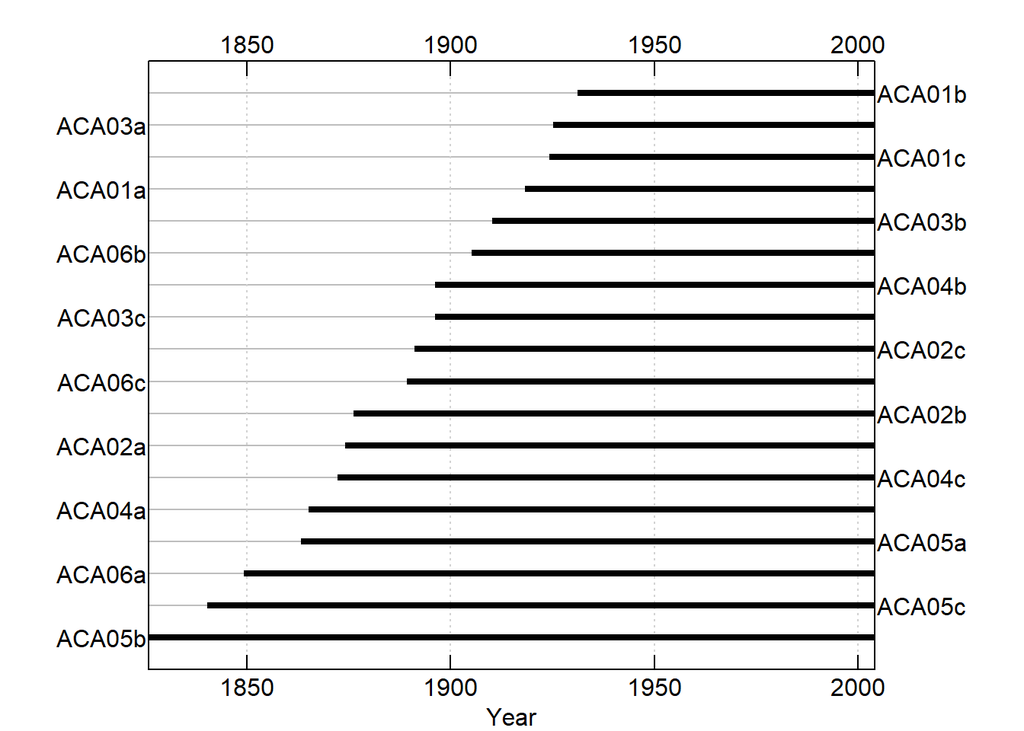

```r
#Statistics of all tree rings measurements.
series_infos <- rwl.stats(series)
write.table(series_infos, file = "DendroSeries_informations.txt")
#Plot the length of all time series
seg.plot(series)
```

```r
#Gives a report of the data
data_statistics <- rwl.report(series)
print(data_statistics)
```

```
## Number of dated series: 18
## Number of measurements: 2123
## Avg series length: 117.9444
## Range:  179
## Span:  1826 - 2004
## Mean (Std dev) series intercorrelation: 0.4737267 (0.07487301)
## Mean (Std dev) AR1: 0.3521667 (0.2348116)
## -------------
## Years with absent rings listed by series
##     None
## -------------
## Years with internal NA values listed by series
##     None
```

```r
capture.output(data_statistics, file = "DendroSeries_Statistics.txt")
```

- *DETRENDING METHODS*

  *Spline - SPL*

```r
#Applies a spline that has a frequency response of 50% at a wavelength of 2/3
FILT_Series.rwi <- detrend(rwl = series, method = c("Spline"), nyrs = NULL, f = 0.5, difference = FALSE)
write.tucson (FILT_Series.rwi, "Detrended-Series_SPL_samples.rwl", prec = 0.01, long.names = TRUE)
```

```
## [1] "Detrended-Series_SPL_samples.rwl"
```

```r
#Calculate statistics for full period Pearson's correlation. EPS, SNR, ETC
Statistics_FILT <- rwi.stats(FILT_Series.rwi,method = c("pearson"))
write.csv(Statistics_FILT, file = "Statistics_SPL_samples.csv")

#Calculate statistics per period using Pearson's correlation. EPS, SNR, ETC
Statistics_FILT_PerPeriod <- rwi.stats.running(FILT_Series.rwi,method = c("pearson"))
write.csv(Statistics_FILT_PerPeriod, file = "StatisticsPerPeriod_SPL_samples.csv")
#Mean sensitivity
msensi1 <- sens1(FILT_Series.rwi)
msensi1 <- data.frame(msensi1)
write.csv(msensi1, file = "MeanSensitivity_SPL_sample.csv")
#Subsample Signal Strength
sss <- sss(FILT_Series.rwi, ids = NULL)
sss <- data.frame(sss)
write.csv(sss, file = "SSS_SPL_sample.csv")
```

*Negative Exponential - NEGEXP*

```r
#Fit a negative exponential curve to a series
FILT_Series.rwi <- detrend(rwl = series, method = "ModNegExp")
write.tucson (FILT_Series.rwi, "Detrended-Series_NEGEXP_samples.rwl", prec = 0.01, long.names = TRUE)
```

```
## [1] "Detrended-Series_NEGEXP_samples.rwl"
```

```r
#Calculate statistics for full period using Pearson's correlation. EPS, SNR, ETC
Statistics_FILT <- rwi.stats(FILT_Series.rwi,method = c("pearson"))
write.csv(Statistics_FILT, file = "Statistics_NEGEXP_samples.csv")

#Calculate statistics per period using Pearson's correlation. EPS, SNR, ETC
Statistics_FILT_PerPeriod <- rwi.stats.running(FILT_Series.rwi,method = c("pearson"))
write.csv(Statistics_FILT_PerPeriod, file = "StatisticsPerPeriod_NEGEXP_samples.csv")
#Mean sensitivity
msensi1 <- sens1(FILT_Series.rwi)
msensi1 <- data.frame(msensi1)
write.csv(msensi1, file = "MeanSensitivity_NEGEXP_sample.csv")
#Subsample Signal Strength
sss <- sss(FILT_Series.rwi, ids = NULL)
sss <- data.frame(sss)
write.csv(sss, file = "SSS_NEGEXP_sample.csv")
```

*Regional Curve Standardization - RCS*

```r
colnames <- colnames(series) #column names
po <- data.frame(colnames,series_infos[,4]) #lenght of each series
#Uses the average of the rings measurements of all trees at each ring age as the expected growth value for each individual tree.
FILT_Series.rwi <- rcs(series, po, nyrs = NULL, f = 0.5, biweight = TRUE, ratios = TRUE,
                      rc.out = FALSE, make.plot = FALSE, rc.in = NULL, check = TRUE)
write.tucson (FILT_Series.rwi, "Detrended-Series_RCS_samples.rwl", prec = 0.01, long.names = TRUE)
```

```
## [1] "Detrended-Series_RCS_samples.rwl"
```

```r
#Calculate statistics for full period using Pearson's correlation. EPS, SNR, ETC
Statistics_FILT <- rwi.stats(FILT_Series.rwi,method = c("pearson"))
write.csv(Statistics_FILT, file = "Statistics_RCS_samples.csv")

#Calculate statistics per period using Pearson's correlation. EPS, SNR, ETC
Statistics_FILT_PerPeriod <- rwi.stats.running(FILT_Series.rwi,method = c("pearson"))
write.csv(Statistics_FILT_PerPeriod, file = "StatisticsPerPeriod_RCS_samples.csv")
#Mean sensitivity
msensi1 <- sens1(FILT_Series.rwi)
msensi1 <- data.frame(msensi1)
write.csv(msensi1, file = "MeanSensitivity_RCS_sample.csv")
#Subsample Signal Strength
sss <- sss(FILT_Series.rwi, ids = NULL)
sss <- data.frame(sss)
write.csv(sss, file = "SSS_RCS_sample.csv")
```

*BUILDING THE CHRONOLOGY*

*Residual or Standardized Chronology*

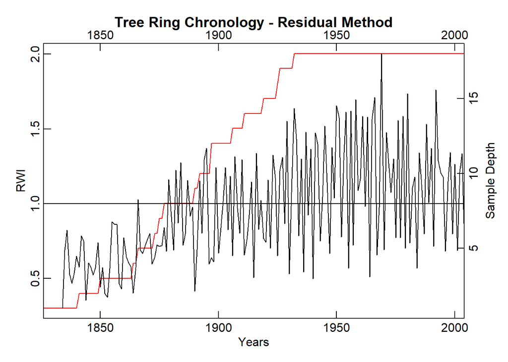

```r
# Residual Chronology - With Auto Regressive Model
chronology.crn <- chron(x = FILT_Series.rwi, prefix = "", biweight = TRUE, prewhiten = TRUE)

#Plot the chronology with sample depth
crn.plot(crn = chronology.crn[,-1], add.spline = FALSE, nyrs = NULL, f = 0.5, crn.line.col='black', spline.line.col='white', samp.depth.col='white', samp.depth.border.col='red', crn.lwd=1.0, include.names = FALSE, xlab="Years", ylab="RWI",main="Tree Ring Chronology - Residual Method")
```

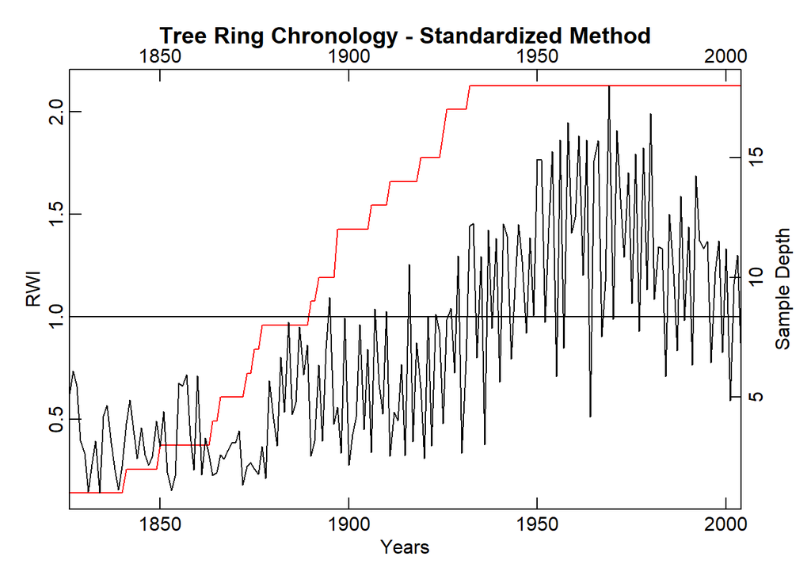

```r
write.table(chronology.crn, file = "Chronology_Residual_Samples.txt")

# Standardized Chronology - Without Auto Regressive Model
#Plot the chronology with sample depth
crn.plot(crn = chronology.crn[,-2], add.spline = FALSE, nyrs = NULL, f = 0.5, crn.line.col='black', spline.line.col='white', samp.depth.col='white', samp.depth.border.col='red', crn.lwd=1.0, include.names = FALSE, xlab="Years", ylab="RWI", main="Tree Ring Chronology - Standardized Method")
```

```r
write.table(chronology.crn, file = "Chronology_Standardized_Samples.txt")
```

*Stardardized Chronology with the Variance Correction*

```r
chron_stabilized.crn <- chron.stabilized(FILT_Series.rwi,
                                winLength=101,
                                biweight = TRUE,
                                running.rbar = FALSE)
```

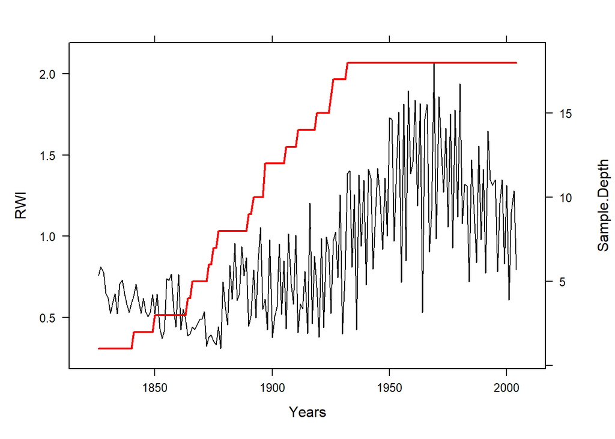

```r
Years <- time(series)
colnames(chron_stabilized.crn) <- c('RWI','Sample.Depth')
# --> construct separate plots for each series
obj1 <- xyplot(RWI ~ Years, chron_stabilized.crn, type = "l" , lwd=1.0, col="black")
obj2 <- xyplot(Sample.Depth ~ Years, chron_stabilized.crn, type = "l", lwd=2, col="red")

# --> Make the plot with second y axis:
doubleYScale(obj1, obj2, add.ylab2 = TRUE, use.style=FALSE, main="Tree Ring Chronology - Standardized Method")
```

```r
write.table(chron_stabilized.crn, file = "Chronology_Stabilized_Samples.txt")
write.tucson(rwl.df = chron_stabilized.crn, fname = tempfile("ChronStab.rwl"),
                      header = NULL, append = FALSE, prec = 0.001)
```

```
## [1] "C:\\Users\\DanyO\\AppData\\Local\\Temp\\RtmpWAxLIZ\\ChronStab.rwldb03c26280c"
```

**Working with Trees Indices**

*Create the tree indices*

```r
a1 <- unique(substr(names(series), 1,5)) #Get unique names (first 5 characters, e.g., ACA01)
#A (Araucaria) - CA (Canela) - 01 (tree number). What changes id the a, b, c, d after the first 5 characters.

emptytemp1 <- rep(NA, nrow(series))



for(n in 1:length(a1))

{

matches <- which(substr(names(series), 1,5) == a1[n]) #Match all series with the same unique name (first 5 characters, e.g., ACA01)

temp <- series[,matches]



  if(length(matches) == 1)

  {

    temp <- as.data.frame(cbind(series[,matches], emptytemp1))

    row.names(temp) <- row.names(series)

  }

  if(n == 1) trees <- as.data.frame(rowMeans(temp, na.rm = TRUE)) #If first series

  if(n > 1) trees <- combine.rwl(trees, as.data.frame(rowMeans(temp, na.rm = TRUE))) #If not first series, then use combine.rwl

}


names(trees) <- a1 # add names to it
```

*Dendrochronological Series Statistics*

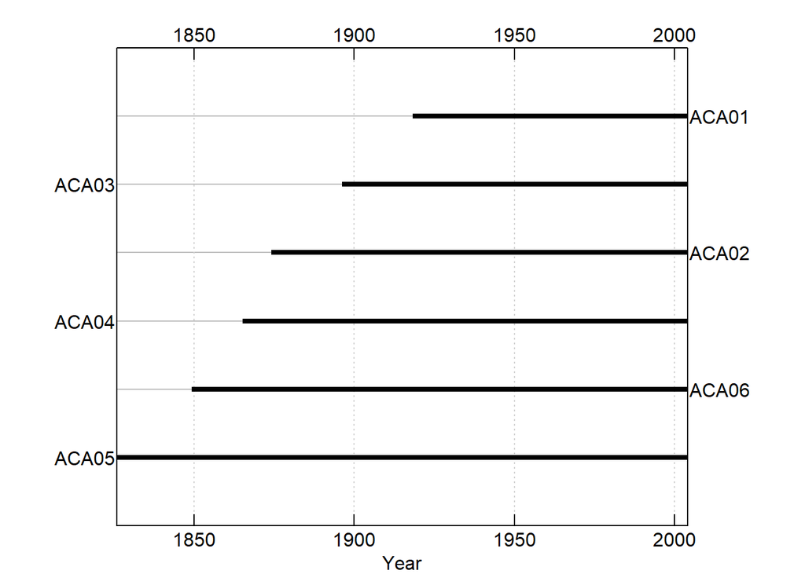

```r
#Statistics of all tree rings measurements
series_infos_trees <- rwl.stats(trees)
write.table(series_infos_trees, file = "DendroSeriesTrees_informations.txt")
#Plot the length of all time series
seg.plot(trees)
```

```r
#Gives a report of the data
data_statistics_trees <- rwl.report(trees)
print(data_statistics_trees)
```

```
## Number of dated series: 6
## Number of measurements: 797
## Avg series length: 132.8333
## Range:  179
## Span:  1826 - 2004
## Mean (Std dev) series intercorrelation: 0.5929746 (0.02272497)
## Mean (Std dev) AR1: 0.2888333 (0.2359453)
## -------------
## Years with absent rings listed by series
##     None
## -------------
## Years with internal NA values listed by series
##     None
```

```r
capture.output(data_statistics_trees, file = "DendroSeriesTrees_Statistics.txt")
```

*DETRENDING METHODS*

*Spline - SPL*

```r
#Applies a spline that has a frequency response of 50% at a wavelength of 2/3
FILT_Series.rwi <- detrend(rwl = trees, method = c("Spline"), nyrs = NULL, f = 0.5, difference = FALSE)
write.tucson (FILT_Series.rwi, "Detrended-Series_SPL_Trees.rwl", prec = 0.01, long.names = TRUE)
```

```
## [1] "Detrended-Series_SPL_Trees.rwl"
```

```r
#Calculate statistics for full period Pearson's correlation. EPS, SNR, ETC
Statistics_FILT <- rwi.stats(FILT_Series.rwi,method = c("pearson"))
write.csv(Statistics_FILT, file = "Statistics_SPL_Trees.csv")

#Calculate statistics per period using Pearson's correlation. EPS, SNR, ETC
Statistics_FILT_PerPeriod <- rwi.stats.running(FILT_Series.rwi,method = c("pearson"))
write.csv(Statistics_FILT_PerPeriod, file = "StatisticsPerPeriod_SPL_Trees.csv")
#write.tucson(rwl.df, fname, header = NULL, append = FALSE,
          #   prec = 0.01, mapping.fname = "", mapping.append = FALSE,
            # long.names = FALSE, ...)
#Mean sensitivity
msensi1 <- sens1(FILT_Series.rwi)
msensi1 <- data.frame(msensi1)
write.csv(msensi1, file = "MeanSensitivity_SPL_Tree.csv")
#Subsample Signal Strength
sss <- sss(FILT_Series.rwi, ids = NULL)
sss <- data.frame(sss)
write.csv(sss, file = "SSS_SPL_Tree.csv")
```

*Negative Exponential - NEGEXP*

```r
#Fit a negative exponential curve to a series
FILT_Series.rwi <- detrend(rwl = trees, method = "ModNegExp")
write.tucson (FILT_Series.rwi, "Detrended-Series_NEGEXP_Trees.rwl", prec = 0.01, long.names = TRUE)
```

```
## [1] "Detrended-Series_NEGEXP_Trees.rwl"
```

```r
#Calculate statistics for full period using Pearson's correlation.
Statistics_FILT <- rwi.stats(FILT_Series.rwi,method = c("pearson"))
write.csv(Statistics_FILT, file = "Statistics_NEGEXP_Trees.csv")

#Calculate statistics per period using Pearson's correlation.
Statistics_FILT_PerPeriod <- rwi.stats.running(FILT_Series.rwi,method = c("pearson"))
write.csv(Statistics_FILT_PerPeriod, file = "StatisticsPerPeriod_NEGEXP_Trees.csv")
#write.tucson(rwl.df, fname, header = NULL, append = FALSE,
       #      prec = 0.01, mapping.fname = "", mapping.append = FALSE,
      #       long.names = FALSE, ...)

#Mean sensitivity
msensi1 <- sens1(FILT_Series.rwi)
msensi1 <- data.frame(msensi1)
write.csv(msensi1, file = "MeanSensitivity_NEGEXP_Tree.csv")
#Subsample Signal Strength
sss <- sss(FILT_Series.rwi, ids = NULL)
sss <- data.frame(sss)
write.csv(sss, file = "SSS_NEGEXP_Tree.csv")
```

*Regional Curve Standardization - RCS*

```r
colnames <- colnames(trees) #column names
po <- data.frame(colnames,series_infos_trees[,4]) #lenght of each series
#Uses the average of the rings measurements of all trees at each ring age as the expected growth value for each individual tree.
FILT_Series.rwi <- rcs(trees, po, nyrs = NULL, f = 0.5, biweight = TRUE, ratios = TRUE,
                      rc.out = FALSE, make.plot = FALSE, rc.in = NULL, check = TRUE)
write.tucson (FILT_Series.rwi, "Detrended-Series_RCS_Trees.rwl", prec = 0.01, long.names = TRUE)
```

```
## [1] "Detrended-Series_RCS_Trees.rwl"
```

```r
#Calculate statistics for full period using Pearson's correlation. EPS, SNR, ETC
Statistics_FILT <- rwi.stats(FILT_Series.rwi,method = c("pearson"))
write.csv(Statistics_FILT, file = "Statistics_RCS_Trees.csv")

#Calculate statistics per period using Pearson's correlation. EPS, SNR, ETC
Statistics_FILT_PerPeriod <- rwi.stats.running(FILT_Series.rwi,method = c("pearson"))
write.csv(Statistics_FILT_PerPeriod, file = "StatisticsPerPeriod_RCS_Trees.csv")
#Mean sensitivity
msensi1 <- sens1(FILT_Series.rwi)
msensi1 <- data.frame(msensi1)
write.csv(msensi1, file = "MeanSensitivity_RCS_Tree.csv")
#Subsample Signal Strength
sss <- sss(FILT_Series.rwi, ids = NULL)
sss <- data.frame(sss)
write.csv(sss, file = "SSS_RCS_Tree.csv")
```

*BUILDING THE CHRONOLOGY*

*Residual or Standardized Chronology*

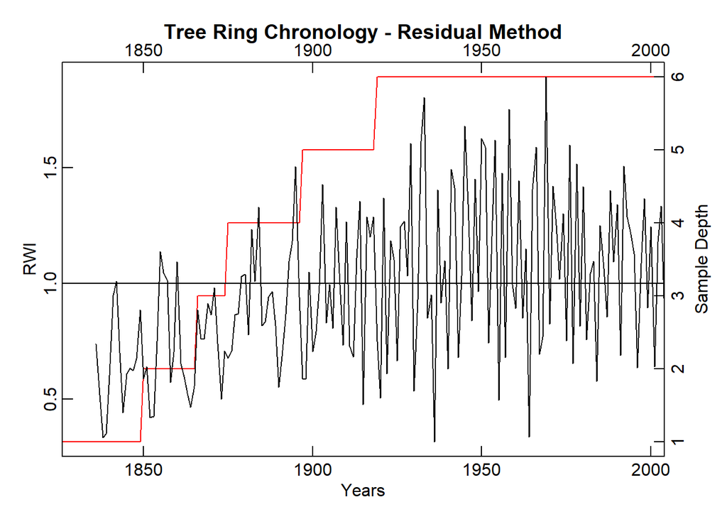

```r
# Residual Chronology - With Auto Regressive Model
chronology.crn <- chron(x = FILT_Series.rwi, prefix = "", biweight = TRUE, prewhiten = TRUE)

#Plot the chronology with sample depth
crn.plot(crn = chronology.crn[,-1], add.spline = FALSE, nyrs = NULL, f = 0.5, crn.line.col='black', spline.line.col='white', samp.depth.col='white', samp.depth.border.col='red', crn.lwd=1.0, include.names = FALSE, xlab="Years", ylab="RWI",main="Tree Ring Chronology - Residual Method")
```

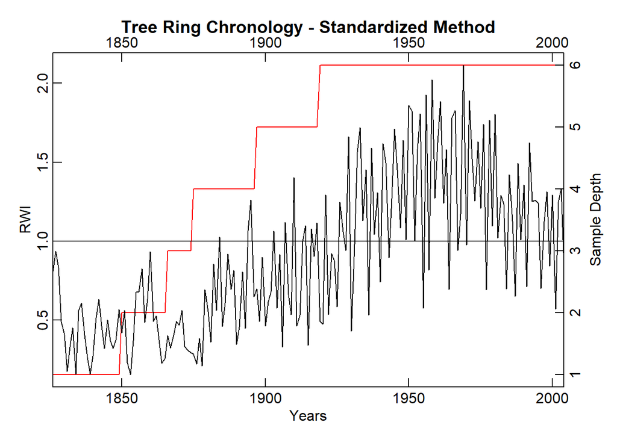

```r
write.table(chronology.crn, file = "Chronology_Residual_Trees.txt")

# Standardized Chronology - Without Auto Regressive Model
#Plot the chronology with sample depth
crn.plot(crn = chronology.crn[,-2], add.spline = FALSE, nyrs = NULL, f = 0.5, crn.line.col='black', spline.line.col='white', samp.depth.col='white', samp.depth.border.col='red', crn.lwd=1.0, include.names = FALSE, xlab="Years", ylab="RWI", main="Tree Ring Chronology - Standardized Method")
```

```r
write.table(chronology.crn, file = "Chronology_Standardized_Trees.txt")
```

*Stardardized Chronology with the Variance Correction*

```r
chron_stabilized.crn <- chron.stabilized(FILT_Series.rwi,
                                winLength=101,
                                biweight = TRUE,
                                running.rbar = FALSE)
```

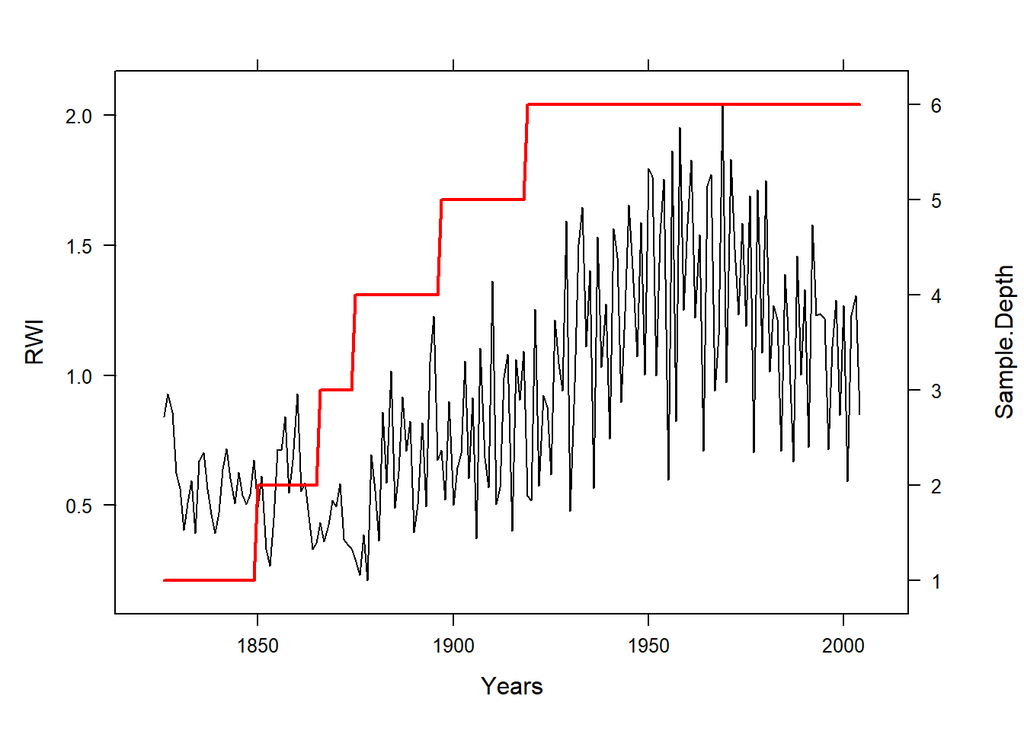

```r
Years <- time(series)
colnames(chron_stabilized.crn) <- c('RWI','Sample.Depth')
# --> construct separate plots for each series
obj1 <- xyplot(RWI ~ Years, chron_stabilized.crn, type = "l" , lwd=1.0, col="black")
obj2 <- xyplot(Sample.Depth ~ Years, chron_stabilized.crn, type = "l", lwd=2, col="red")

# --> Make the plot with second y axis:
doubleYScale(obj1, obj2, add.ylab2 = TRUE, use.style=FALSE, main="Canela Tree-Ring Chronology")
```

```r
write.table(chron_stabilized.crn, file = "Chronology_Stabilized_Trees_canela.txt")
write.tucson(rwl.df = chron_stabilized.crn, fname = tempfile("ChronStab.rwl"),
                      header = NULL, append = FALSE, prec = 0.001)
```

```
## [1] "C:\\Users\\DanyO\\AppData\\Local\\Temp\\RtmpWAxLIZ\\ChronStab.rwldb017b3c60"
```